# Perceptron

Kyle Safran

May 13, 2017

## Introduction

The perceptron is a simple binary classification model, usually taught as an introduction to neural networks or SVMs. The model classifies data according to the simple linear decision boundary:

[figure not shown]

## Algorithm

We can use Rozenblatt’s perceptron learning algorithm to find a separating hyperplane as long as the two classes are linearly separable. If y is labeled either -1 or 1, and M is the set of all misclassified points, we want to minimize the following

$$-\sum_{i \in M} y_i(x_i^Tb+b_0)$$
This is basically just minimizing the distance of the misclassified points to the decision boundary. We find this minimum by stochastic gradient descent, meaning that we update the parameters by using the gradient from one misclassified observation at a time. The gradient for each point is simply
$$-y_ix_i$$
, and our steps in this direction will be muted by a multiplicative learning rate p (0,1). For more details, see [ESL](http://statweb.stanford.edu/~tibs/ElemStatLearn/printings/ESLII_print10.pdf), page 130.

## Implementation

For this algorithm to converge, we need some data that is linearly separable. Let’s use the iris data set - we can see below that the setosa and versicolor species are both linearly separable by Sepal Length and Sepal Width.

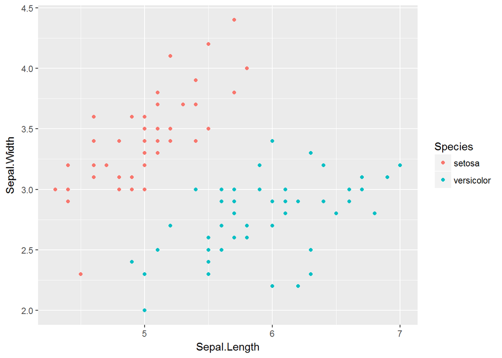

```r
ggplot(iris %>% filter(Species != 'virginica')) +
  geom_point(aes(x = Sepal.Length, y = Sepal.Width, col = Species))
```

First, we need to set up our data for use in the algorithm. It’s not so important in this particular case, but we want to scale our data before implementing this algorithm. We also want our model matrix to include and intercept column.

```r
iris.perceptron <- iris %>%
  filter(Species != 'virginica') %>%
  mutate(Sepal.Length = scale(Sepal.Length),
         Sepal.Width = scale(Sepal.Width),
         label = ifelse(Species == 'setosa', 1, -1))
iris.matrix <- model.matrix(label ~ Sepal.Length + Sepal.Width,
                            data = iris.perceptron)
head(iris.matrix)
```

```
##   (Intercept) Sepal.Length  Sepal.Width
## 1           1   -0.5781533  0.837617378
## 2           1   -0.8898262 -0.206793318
## 3           1   -1.2014991  0.210970961
## 4           1   -1.3573356  0.002088821
## 5           1   -0.7339897  1.046499517
## 6           1   -0.1106439  1.673145934
```

Next, let’s implement a perceptron function. This should take in the data matrix and a vector of parameters, and return a classification of either 1 or -1.

```r
perceptron <- function(data, betas){
  sign(data %*% betas)
}
```

## Initialization

First, we will initialize our boundary with some random parameter values, and plot our boundary.

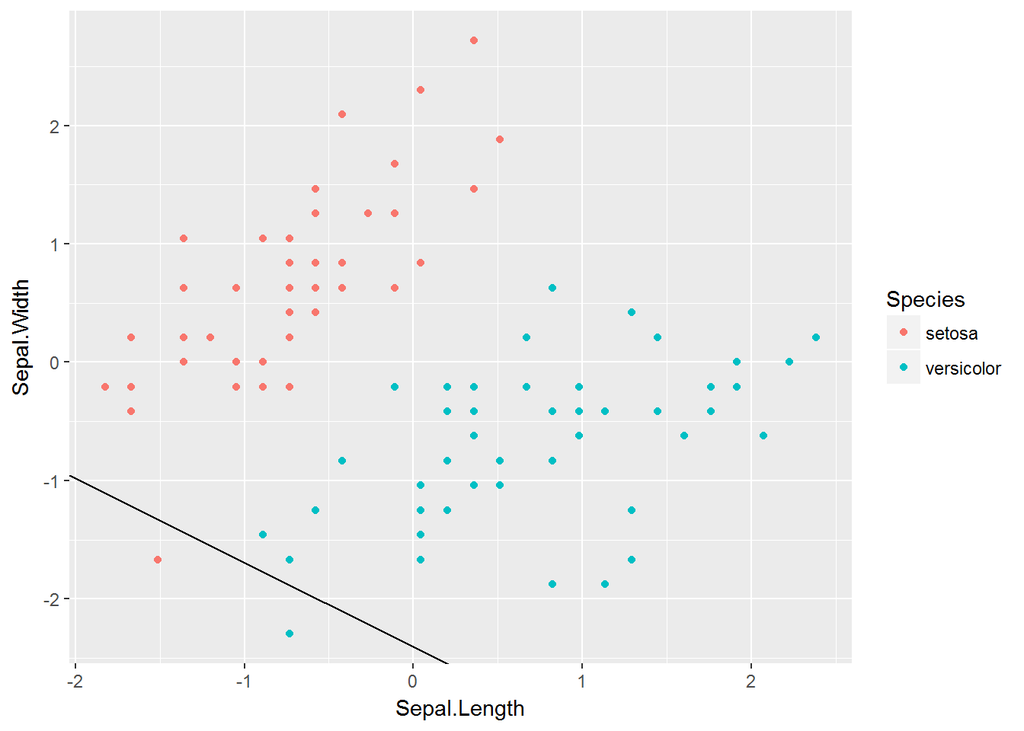

Well this is a pretty bad starting point, so let’s start running through our misclassified points and updating our boundary. Let’s pick a misclassified point to update

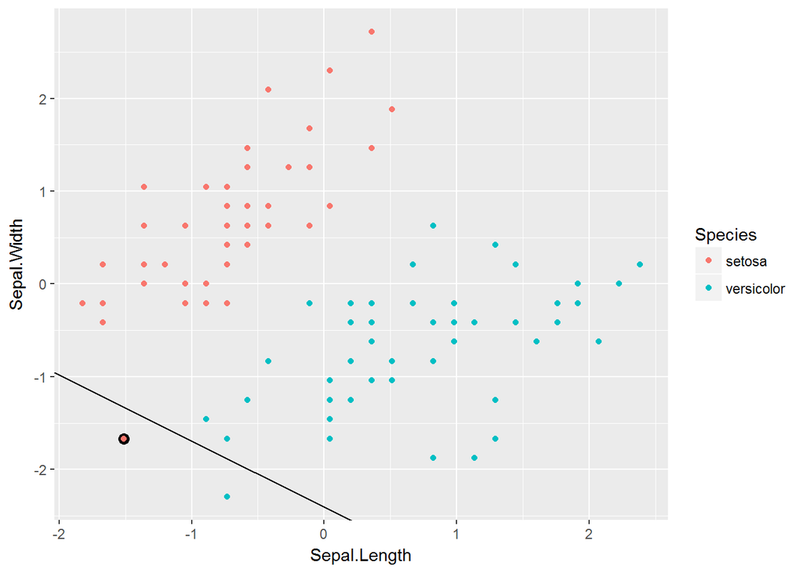

```r
iris.perceptron$prediction = perceptron(iris.matrix, beta.init)
missed <- iris.perceptron[iris.perceptron$prediction != iris.perceptron$label,]

ggplot() +
  geom_point(aes(x = Sepal.Length, y = Sepal.Width), col = 'black', size = 3,
             data = missed[1,]) +
  geom_point(aes(x = Sepal.Length, y = Sepal.Width, col = Species),
             data = iris.perceptron) +
# Our line is defined by t(B)*x = 0, so x2 = -b0/b2 - b1/b2x1
  geom_abline(intercept = -(beta.init[1]/beta.init[3]),
              slope = -(beta.init[2]/beta.init[3]),
              data = iris.perceptron)
```

Now we want to update our betas by taking a step in the direction of the gradient for this point.

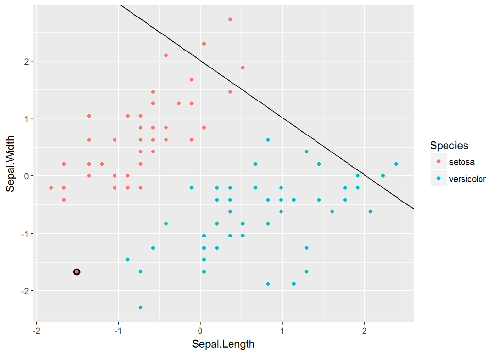

```r
p <- 0.7
beta.update = beta.init + p * missed[1, 'label'] * c(1, missed$Sepal.Length[1],
                                                     missed$Sepal.Width[1])
ggplot() +
  geom_point(aes(x = Sepal.Length, y = Sepal.Width), col = 'black', size = 3,
             data = missed[1,]) +
  geom_point(aes(x = Sepal.Length, y = Sepal.Width, col = Species),
             data = iris.perceptron) +
# Our line is defined by t(B)*x = 0, so x2 = -b0/b2 - b1/b2x1
  geom_abline(intercept = -(beta.update[1]/beta.update[3]),
              slope = -(beta.update[2]/beta.update[3]),
              data = iris.perceptron)
```

It’s not obvious that that is a much better decision boundary, but after we iterate through our entire training set one time, we should be able to see a significant improvement. One thing to note about this learning algorithm, that I don’t see explicitly stated often, is that you run through each point in your training set sequentially, updating your weights after each point, and then evaluating the next point with your updated weights. If that’s not totally clear, the following code runs through the process.

```r
p <- 0.7
# Let's save the output of beta.update in a matrix
beta.update <- t(replicate(nrow(iris.matrix) + 1, beta.init))
for(i in 1:nrow(iris.matrix)){
  # First, evaluate the algorithm with current weights.
  iris.perceptron$prediction <- perceptron(iris.matrix, beta.update[i, ])
  if(i %% 10 == 0){
    print(paste('Error = ',sum(iris.perceptron$prediction != iris.perceptron$label)))
  }
  # If the current observation is misclassified, update our betas
  if(iris.perceptron$prediction[i] != iris.perceptron$label[i]){
    beta.update[i + 1, ] <-  beta.update[i, ] + (p * iris.perceptron$label[i] * c(1,        iris.perceptron$Sepal.Length[i], iris.perceptron$Sepal.Width[i]))
  } else {
    beta.update[i + 1, ] <- beta.update[i, ]
  }
}
```

```
## [1] "Error =  50"
## [1] "Error =  50"
## [1] "Error =  50"
## [1] "Error =  50"
## [1] "Error =  51"
## [1] "Error =  1"
## [1] "Error =  1"
## [1] "Error =  1"
## [1] "Error =  1"
## [1] "Error =  1"
```

Great, we saw the error decrease dramatically. This algorithm should converge on the boundary eventually, but this should still be a pretty good separator. Let’s plot it and see what we have.

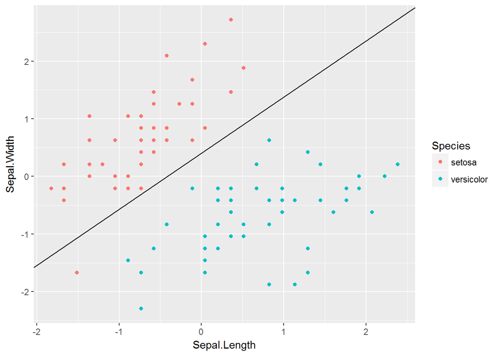

```r
ggplot() +
  geom_point(aes(x = Sepal.Length, y = Sepal.Width, col = Species),
             data = iris.perceptron) +
# Our line is defined by t(B)*x = 0, so x2 = -b0/b2 - b1/b2x1
  geom_abline(intercept = -(beta.update[101, 1]/beta.update[101, 3]),
              slope = -(beta.update[101,2]/beta.update[101, 3]),
              data = iris.perceptron)
```